# Capstone Data Science Project

Pedro Medeiros

2025-02-10

## 1. Introduction

The objective of the Capstone Project is to develop a text predictive data product. The data used is a collection of text documents, called a Corpus. The corpus that will be used for this milestone report has been made available by HC Corpora through the Coursera website.

The goal of this report is to perform exploratory analysis to understand statistical properties of the data set that can later be used when building the prediction model for the final Shiny application. Here we will identify the major features of the training data and then summarize plans for the predictive model.

## 2. Loading, Cleaning and Summarizing the Data

Understanding the characteristics of the acquired data is important, as it will elucidate as to how the data should be cleaned and preprocessed for analysis.

The documents downloaded are zipped text files. The text files are grouped into folders by language. The folder of interest to us will be the English US folder. In this folder there are three files, text documents, that contain text gathered from three sources - blogs, news and twitter - and the model will be trained using that same data.

The following table outlines the size of the files, characters, Words and the number of lines each document has.

Summary of Text Datasets

| File | FileSize | Lines | Characters | Words |
| --- | --- | --- | --- | --- |
| en_US.blogs.txt | 200 MB | 899288 | 206824505 | 37570839 |
| en_US.news.txt | 196 MB | 77259 | 15639408 | 2651432 |
| en_US.twitter.txt | 159 MB | 2360148 | 162096241 | 30451170 |

## 3. Preprocessing the sample sets

Prior to performing exploratory data analysis, the three data sets will be sampled to improve performance.

Summary of Sampled Dataset

| File | FileSize | Lines | Characters | Words |
| --- | --- | --- | --- | --- |
| en_US.sample.txt | 0.75 MB | 6674 | 774790 | 141721 |

A custom function named buildCorpus will be employed to perform the following transformation steps for each document:

```
1. Remove URL, Twitter handles and email patterns by converting them to spaces using a custom content transformer
2. Convert all words to lowercase
3. Remove common English stop words
4. Remove punctuation marks
5. Remove numbers
6. Trim whitespace
7. Remove profanity
8. Convert to plain text documents
```

## 4. Word Frequencies or Exploratory Data Analysis

Exploratory data analysis will be performed to fulfill the primary goal for this report. Several techniques will be employed to develop an understanding of the training data which include looking at the most frequently used words, tokenizing and n-gram generation.

A bar chart and word cloud will be constructed to illustrate unique word frequencies.

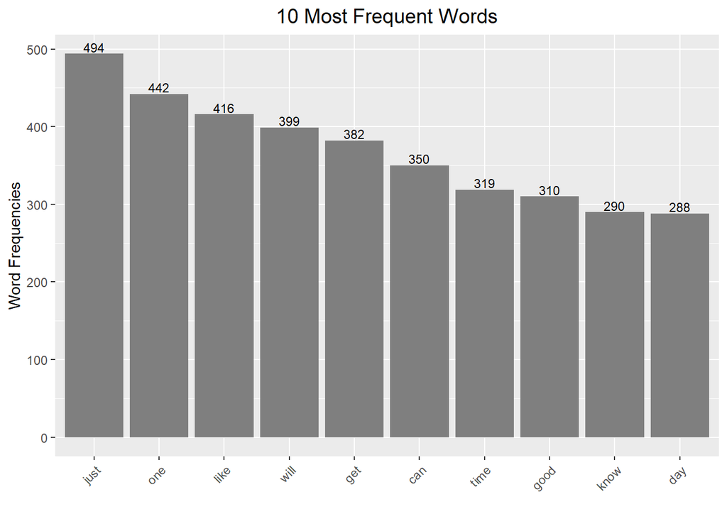

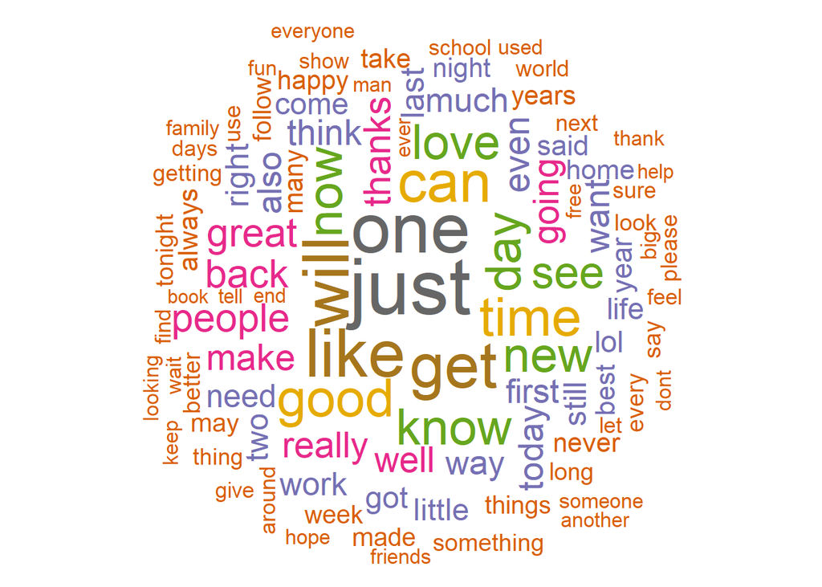

### 4.1 Exploratory analysis of tokens

The predictive model I plan to develop for the Shiny application will handle uniqrams, bigrams, and trigrams. In this section, I will use the RWeka package to construct functions that tokenize the sample data and construct matrices of uniqrams, bigrams, and trigrams. Tokenization is defined as taking a string and breaking it up into smaller parts. The parts could be, words, phrases or radicals of words as examples. Tokens are then used as the building blocks in understanding how text is structured and how tokens are related to each other. Therefore the objective is to understand what tokens to use and how they appear in the text and with what frequency.

#### Tokenize Functions

The following graphs represent the most common 20 unigrams, bigrams or trigrams by frequency count.

#### Unigrams

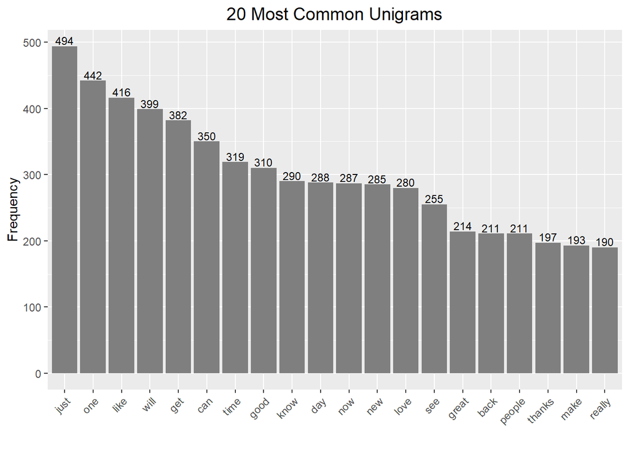

#### Bigrams

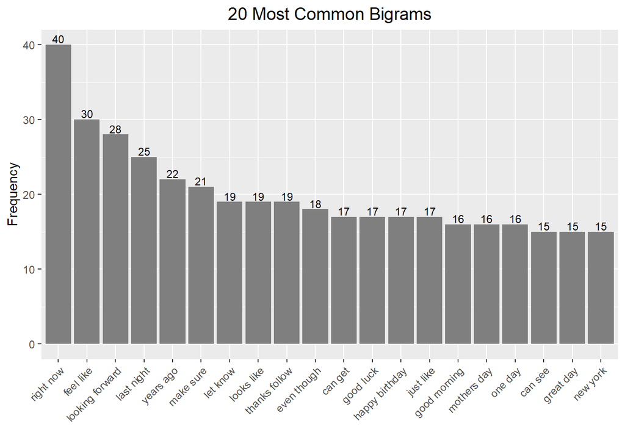

#### Trigrams

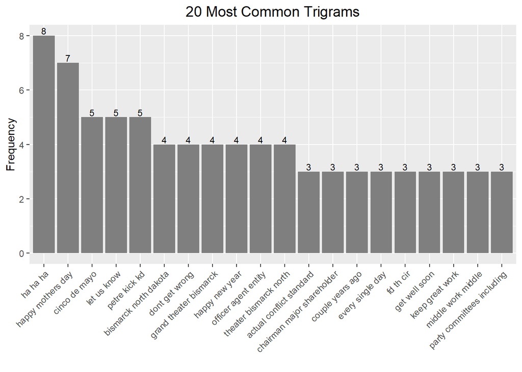

The final deliverable in the capstone project is to build a predictive algorithm that will be deployed as a Shiny app for the user interface. The Shiny app should take as input a phrase (multiple words) in a text box input and output a prediction of the next word.

The predictive algorithm will be developed using an n-gram model with a word frequency lookup similar to that performed in the exploratory data analysis section of this report. A strategy will be built based on the knowledge gathered during the exploratory analysis. For example, as n increased for each n-gram, the frequency decreased for each of its terms. So one possible strategy may be to construct the model to first look for the unigram that would follow from the entered text. Once a full term is entered followed by a space, find the most common bigram model and so on.

The final strategy will be based on the one that increases efficiency and provides the best accuracy.